# WSL2(windows subsystem for linux) 上のubuntu18.04でwebotsをインストールしRosでロボットを動かせるようにする

###### 48216537 中野

Webotsはwindowsで動かせますが、ROSがwindowsに対応していないので、windows上にlinux環境を構築して、WebotsとROSをインストールします。

全体的な流れは

1. WSL2のセットアップ
2. Xサーバ(描画用)をインストール
3. Webotsをインストール
4. Rosインストール

です。

1,2については以下のURLの手順3までに対応します。

https://qiita.com/Engr_Coal33/items/16a293a6855d02366c1c

ちなみに、起動するときは Ubuntuのバージョンは18.04にしました。

```python
$xeyes
```

と打ち込んで目が表示されればこれまでの手順はOKです。

3については以下の公式リファレンスに従います。  
https://www.cyberbotics.com/doc/guide/installation-procedure#installation-on-linux

認証

```python
$ wget -qO- https://cyberbotics.com/Cyberbotics.asc | sudo apt-key add -
```

リポジトリの追加と更新

```python
$ sudo apt-add-repository 'deb https://cyberbotics.com/debian/ binary-amd64/'
$ sudo apt update
```

インストール

```python
$ sudo apt install webots
```

です。そして

```python
$webot
```

でwebotsが立ち上がるはずです。

この時に

```python
ERROR: OpenGL version 1.5 or higher required
```

と出る場合があります。これの対策のためVcXsrvの起動時にNative openglのチェックを外す必要があります。(起動時のセットアップ画面は以下参照)

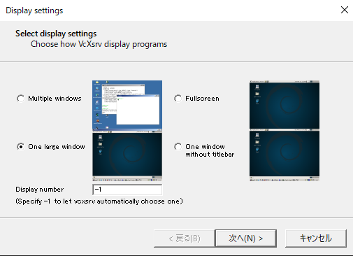

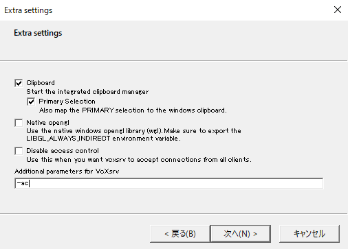

私はこれでいけましたが、それでもだめなら https://qiita.com/momomo_rimoto/items/2841f1f15d364c2377a1  
に基づいて,以下のコマンドを実行します.

```python
unset LIBGL_ALWAYS_INDIRECT
```

4については公式リファレンスのチュートリアル8に従います。 https://www.cyberbotics.com/doc/guide/tutorial-8-using-ros UbuntuとROSのバージョンの対応は

| Ubuntu | ROS |
| --- | --- |
| 20.04 | Noetic |
| 18.04 | Melodic |
| 16.04 | Kinetic |

となっています.ですので,ここではMelodicを用います。あとはチュートリアル通りです

##### おわりに

いろいろと参照を提示しましたが、いろいろなところで詰まると思います。。。